# Mediation Analysis Example: Glul

Gary A. Churchill

## Introduction

We will explore mediation analysis in RNA and protein expression data from [Diversity Outbred (DO) Mice](http://jaxmice.jax.org/strain/009376.html).

## Libraries and Data Import

Load the libraries for [ggplot2](http://ggplot2.org/) and [DOQTL](http://www.bioconductor.org/packages/release/bioc/html/DOQTL.html)

```r
library(DOQTL)
library(ggplot2)
```

Load the DO data.

```r
load("/data/Rdata/DO192_DataforSysGenCourse.Rdata")
```

Convert sex and diet to numeric variables (0 = Female, 1 = male).

```r
Sex <- as.numeric(factor(covariates.rna.192$Sex))-1
Diet <- as.numeric(factor(covariates.rna.192$Diet))-1
```

Create numerical indices for chromosome annotations.

```r
annotations.rna.192 <- transform(annotations.rna.192, Chr.num =  as.numeric(ifelse(Chr=="X", "20", Chr)))
annotations.protein.192 <- transform(annotations.protein.192, Chr.num = as.numeric(ifelse(Chromosome.Name=="X", "20", Chromosome.Name)))
```

## RNA and Protein Trait Analysis

What covariates are available?

```r
head(covariates.protein.192)
```

```
##      Sex Diet Sdinteraction Tag Batch   Protein.Quant.Label Cap.No.
## F326   F chow             1   9     2 S01~rq_130a_sn_scaled      18
## F327   F chow             1   9     6 S05~rq_130a_sn_scaled      54
## F328   F chow             1   8     5 S04~rq_129b_sn_scaled      44
## F329   F chow             1   3     3 S02~rq_127a_sn_scaled      21
## F330   F chow             1   5     9 S08~rq_128a_sn_scaled      77
## F331   F chow             1   4    10 S09~rq_127b_sn_scaled      85
##      Mouse.No. Concatenated.Code TMT.Set TMT.label Index
## F326       326              18FS      S1      130a    18
## F327       327              54FS      S5      130a    58
## F328       328              44FS      S4      129b    47
## F329       329              21FS      S2      127a    22
## F330       330              77FS      S8      128a    84
## F331       331              85FS      S9      127b    93
```

```r
head(covariates.rna.192)
```

```
##      Sex Diet Sdinteraction Batch   Gen Coat.Color
## F326   F chow             1     2 G11L1      black
## F327   F chow             1     2 G11L1      black
## F328   F chow             1     2 G11L1      white
## F329   F chow             1     2 G11L1     agouti
## F330   F chow             1     2 G11L1     agouti
## F331   F chow             1     2 G11L1      black
```

Create a dataframe with Glul, the gene of interest.

```r
mydata <- transform(covariates.rna.192,
                    Glul.r = expr.rna.192[,which(annotations.rna.192$Gene == "Glul")],
                    Glul.p = expr.protein.192[,which(annotations.protein.192$Associated.Gene.Name == "Glul")],
                    Sex = as.factor(Sex), Diet = as.factor(Diet),
                    SexDiet = factor(Sdinteraction, labels=c("FC", "FH", "MC", "MH")),
                    Parity = as.factor(Gen), Black = (Coat.Color=="black"), White = (Coat.Color=="white"),
                    Prot.Tag = covariates.protein.192$Tag, Prot.Batch = covariates.protein.192$Batch)
mydata <- mydata[,-c(3,4,6)]
str(mydata)
```

```
## 'data.frame':    192 obs. of  11 variables:
##  $ Sex       : Factor w/ 2 levels "F","M": 1 1 1 1 1 1 1 1 1 1 ...
##  $ Diet      : Factor w/ 2 levels "chow","HF": 1 1 1 1 1 1 1 1 1 1 ...
##  $ Gen       : chr  "G11L1" "G11L1" "G11L1" "G11L1" ...
##  $ Glul.r    : num  0.0455 0.9503 0.216 -0.6145 -0.5989 ...
##  $ Glul.p    : num  0.7285 0.0325 -0.4355 -0.5529 0.6145 ...
##  $ SexDiet   : Factor w/ 4 levels "FC","FH","MC",..: 1 1 1 1 1 1 1 1 1 1 ...
##  $ Parity    : Factor w/ 2 levels "G11L1","G11L2": 1 1 1 1 1 1 1 1 1 1 ...
##  $ Black     : logi  TRUE TRUE FALSE FALSE FALSE TRUE ...
##  $ White     : logi  FALSE FALSE TRUE FALSE FALSE FALSE ...
##  $ Prot.Tag  : int  9 9 8 3 5 4 10 1 8 9 ...
##  $ Prot.Batch: int  2 6 5 3 9 10 7 18 7 20 ...
```

Boxplots suggest a diet effect on Glul is stronger in males.

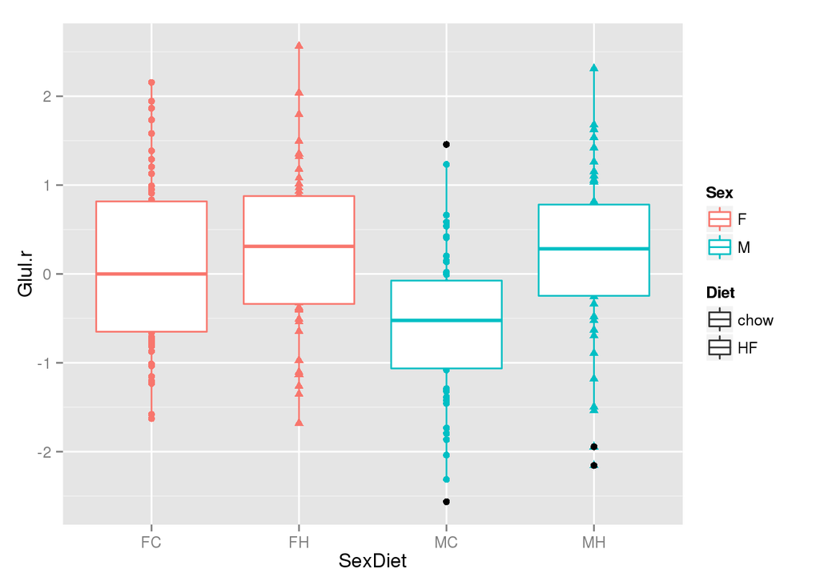

```r
qplot(SexDiet, color=Sex, shape=Diet, Glul.r, data=mydata) + geom_boxplot()
```

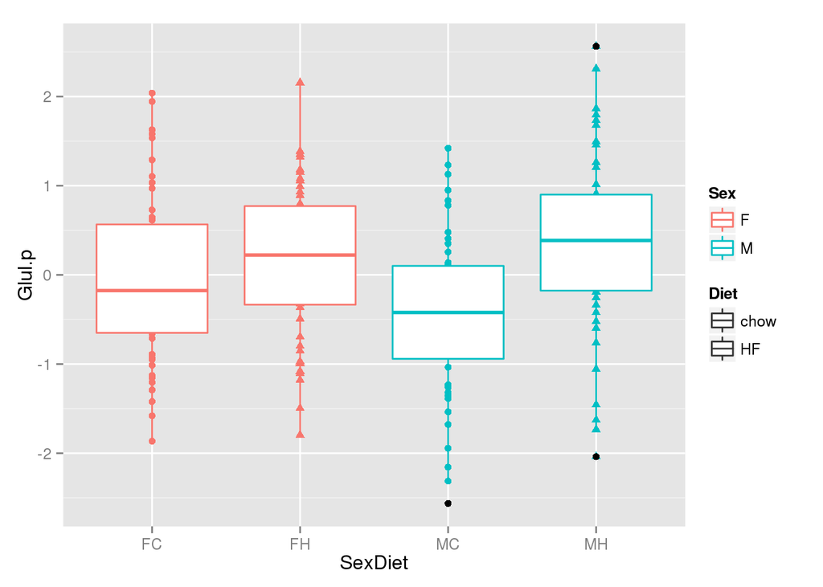

```r
qplot(SexDiet, color=Sex, shape=Diet, Glul.p, data=mydata) + geom_boxplot()
```

Run the sex-by-diet ANOVA to confirm diet and sex effects.

```r
anova(lm(Glul.r ~ Sex*Diet, data=mydata))
```

```
## Analysis of Variance Table
##
## Response: Glul.r
##            Df  Sum Sq Mean Sq F value   Pr(>F)
## Sex         1   6.799  6.7988  7.9618 0.005291 **
## Diet        1  11.225 11.2255 13.1457 0.000371 ***
## Sex:Diet    1   4.528  4.5277  5.3022 0.022393 *
## Residuals 188 160.539  0.8539
## ---
## Signif. codes:  0 '***' 0.001 '**' 0.01 '*' 0.05 '.' 0.1 ' ' 1
```

```r
anova(lm(Glul.p ~ Sex*Diet, data=mydata))
```

```
## Analysis of Variance Table
##
## Response: Glul.p
##            Df  Sum Sq Mean Sq F value    Pr(>F)
## Sex         1   0.771  0.7705  0.8746 0.3508728
## Diet        1  12.530 12.5304 14.2234 0.0002173 ***
## Sex:Diet    1   4.167  4.1669  4.7299 0.0308910 *
## Residuals 188 165.623  0.8810
## ---
## Signif. codes:  0 '***' 0.001 '**' 0.01 '*' 0.05 '.' 0.1 ' ' 1
```

Check for tag and batch effects on protein.

```r
anova(lm(Glul.p ~ Prot.Tag, data=mydata))
```

```
## Analysis of Variance Table
##
## Response: Glul.p
##            Df  Sum Sq Mean Sq F value Pr(>F)
## Prot.Tag    1   0.004 0.00367  0.0038 0.9509
## Residuals 190 183.087 0.96362
```

```r
anova(lm(Glul.p ~ Prot.Batch, data=mydata))
```

```
## Analysis of Variance Table
##
## Response: Glul.p
##             Df Sum Sq Mean Sq F value Pr(>F)
## Prot.Batch   1   0.00 0.00047   5e-04 0.9824
## Residuals  190 183.09 0.96363
```

P-values near 1.0 suggest data have been normalized.

Create scatterplots of RNA and protein.

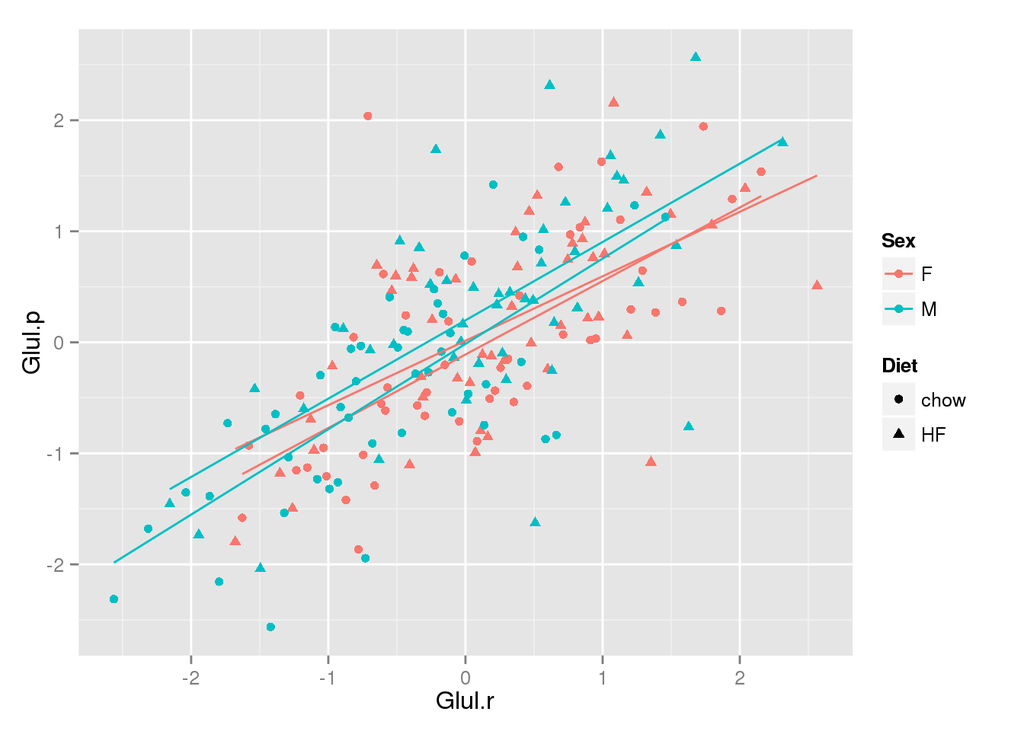

```r
qplot(Glul.r, Glul.p, color=Sex, shape=Diet, data=mydata) + geom_smooth(method="lm", se=FALSE)
```

The correlation of RNA and protein is 0.69.

```r
with(mydata, cor(Glul.r, Glul.p))
```

```
## [1] 0.6946043
```

## Genome Scan Analysis of Glul

The location of Glul is Chr 1 at 153.9Mb.

```r
annotations.rna.192[which(annotations.rna.192$Gene == "Glul"),]
```

```
##                             EnsemblID Gene Chr Start.Mbp  End.Mbp
## ENSMUSG00000026473 ENSMUSG00000026473 Glul   1  153.8999 153.9097
##                      Gene.Biotype Strand Mean.per.Expr Nonzeros Chr.num
## ENSMUSG00000026473 protein_coding      1      142.6531      192       1
```

Create a covariate data structure.

```r
covs <- data.frame(cbind(Sex, Diet))
rownames(covs) <- rownames(mydata)
```

Mediation analysis of Glul.r and Glul.p is carried out in 4-steps using genome scans

1. RNA ~ Q
2. Prot ~ Q
3. RNA ~ Q | Prot
4. Prot ~ Q | RNA

A note on genome scans: no kinship correction - checked and it doesn’t seem to matter much.

### Step 1: scan Glul RNA

```r
Glul.r.scan <- scanone(pheno=mydata, pheno.col="Glul.r", probs=probs.192,
                       addcovar=covs, snps=snps.64K)
```

```
## [1] "Mapping with 192 samples."
## [1] "Mapping with 64000 markers."
## [1] "Glul.r"
```

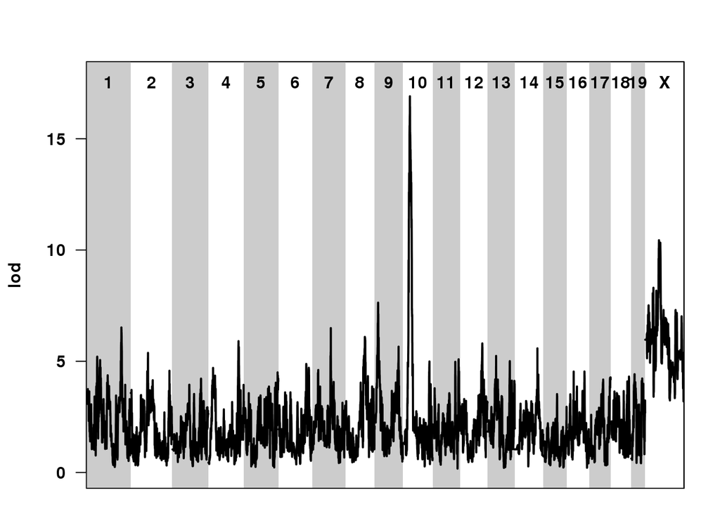

```r
plot(Glul.r.scan)
```

Look at the structure of the scan output.

```r
str(Glul.r.scan)
```

```
## List of 2
##  $ lod :List of 2
##   ..$ A:'data.frame':    60650 obs. of  9 variables:
##   .. ..$ SNP_ID     : chr [1:60650] "1_40055" "1_87283" "1_134512" "1_181741" ...
##   .. ..$ Chr        : chr [1:60650] "1" "1" "1" "1" ...
##   .. ..$ Mb_NCBI38  : num [1:60650] 0.0401 0.0873 0.1345 0.1817 0.229 ...
##   .. ..$ cM         : num [1:60650] 0 0.0238 0.0477 0.0715 0.0953 ...
##   .. ..$ perc.var   : num [1:60650] 8.26 8.26 8.26 8.26 8.26 ...
##   .. ..$ lrs        : num [1:60650] 16.5 16.5 16.5 16.5 16.5 ...
##   .. ..$ lod        : num [1:60650] 3.59 3.59 3.59 3.59 3.59 ...
##   .. ..$ p          : num [1:60650] 0.0206 0.0206 0.0206 0.0206 0.0206 ...
##   .. ..$ neg.log10.p: num [1:60650] 1.69 1.69 1.69 1.69 1.69 ...
##   ..$ X:'data.frame':    3350 obs. of  9 variables:
##   .. ..$ SNP_ID     : chr [1:3350] "X_239226" "X_290225" "X_341223" "X_392221" ...
##   .. ..$ Chr        : chr [1:3350] "X" "X" "X" "X" ...
##   .. ..$ Mb_NCBI38  : num [1:3350] 0.239 0.29 0.341 0.392 0.443 ...
##   .. ..$ cM         : num [1:3350] 0 0.0238 0.0477 0.0715 0.0953 ...
##   .. ..$ perc.var   : num [1:3350] 13.3 13.3 13.3 13.3 13.3 ...
##   .. ..$ lrs        : num [1:3350] 27.5 27.5 27.5 27.5 27.5 ...
##   .. ..$ lod        : num [1:3350] 5.97 5.97 5.97 5.97 5.97 ...
##   .. ..$ p          : num [1:3350] 0.0166 0.0166 0.0166 0.0166 0.0166 ...
##   .. ..$ neg.log10.p: num [1:3350] 1.78 1.78 1.78 1.78 1.78 ...
##  $ coef:List of 2
##   ..$ A: num [1:60650, 1:10] 0.091 0.091 0.091 0.091 0.091 ...
##   .. ..- attr(*, "dimnames")=List of 2
##   .. .. ..$ : chr [1:60650] "1_40055" "1_87283" "1_134512" "1_181741" ...
##   .. .. ..$ : chr [1:10] "Intercept" "Sex" "Diet" "B" ...
##   ..$ X: num [1:3350, 1:16] -0.254 -0.254 -0.254 -0.254 -0.254 ...
##   .. ..- attr(*, "dimnames")=List of 2
##   .. .. ..$ : chr [1:3350] "X_239226" "X_290225" "X_341223" "X_392221" ...
##   .. .. ..$ : chr [1:16] "Intercept" "Diet" "F.B" "F.C" ...
##  - attr(*, "class")= chr [1:2] "doqtl" "list"
##  - attr(*, "model")= chr "additive"
```

whooey!

Find the lod peak.

```r
indx.maxr <- with(Glul.r.scan$lod$A, which(lod==max(lod)))
Glul.r.scan$lod$A[indx.maxr,]
```

```
##                  SNP_ID Chr Mb_NCBI38       cM perc.var      lrs      lod
## 10_30766019 10_30766019  10  30.76602 17.15718 33.34048 77.86988 16.90923
##                        p neg.log10.p
## 10_30766019 3.741888e-14    13.42691
```

The LOD score at the peak is 16.91.

### Step 2: scan Glul protein.

```r
Glul.p.scan <- scanone(pheno=mydata, pheno.col="Glul.p", probs=probs.192,
                       addcovar=covs, snps=snps.64K)
```

```
## [1] "Mapping with 192 samples."
## [1] "Mapping with 64000 markers."
## [1] "Glul.p"
```

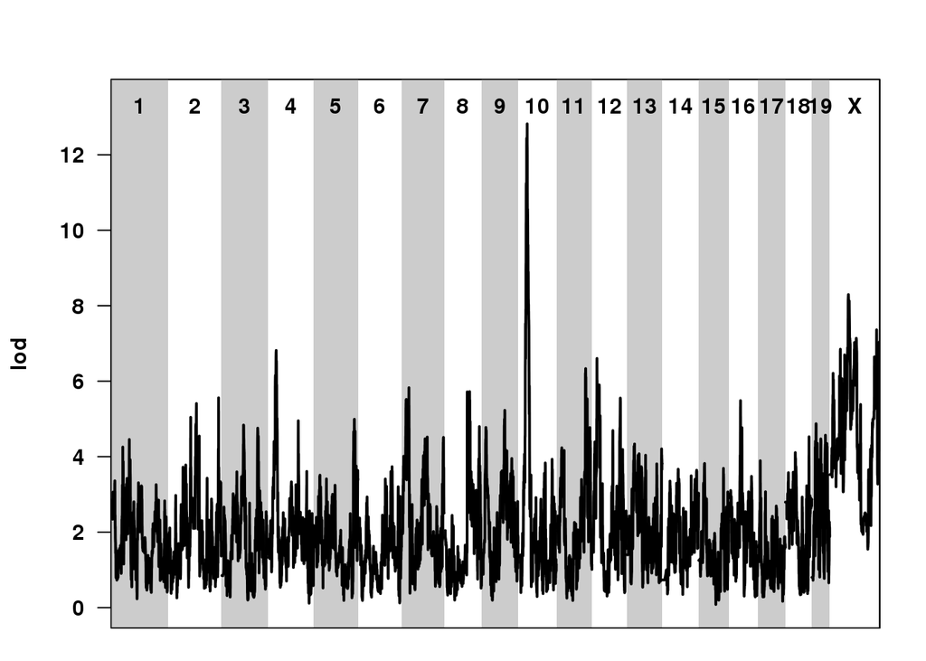

```r
plot(Glul.p.scan)
```

Find the lod peak

```r
indx.maxp <- with(Glul.p.scan$lod$A, which(lod==max(lod)))
Glul.p.scan$lod$A[indx.maxr,]
```

```
##                  SNP_ID Chr Mb_NCBI38       cM perc.var      lrs      lod
## 10_30766019 10_30766019  10  30.76602 17.15718 26.47066 59.03725 12.81978
##                        p neg.log10.p
## 10_30766019 2.349325e-10    9.629057
```

Note that the peak location is the same. The LOD score is lower: 12.82.

### Step 3: scan Glul RNA conditioned on protein

Modify covariates for conditional scan.

```r
covs <- data.frame(cbind(covs[,1:2],mydata$Glul.p))
Glul.r.condp.scan <- scanone(pheno=mydata, pheno.col="Glul.r", probs=probs.192,
                             addcovar=covs, snps=snps.64K)
```

```
## [1] "Mapping with 192 samples."
## [1] "Mapping with 64000 markers."
## [1] "Glul.r"
```

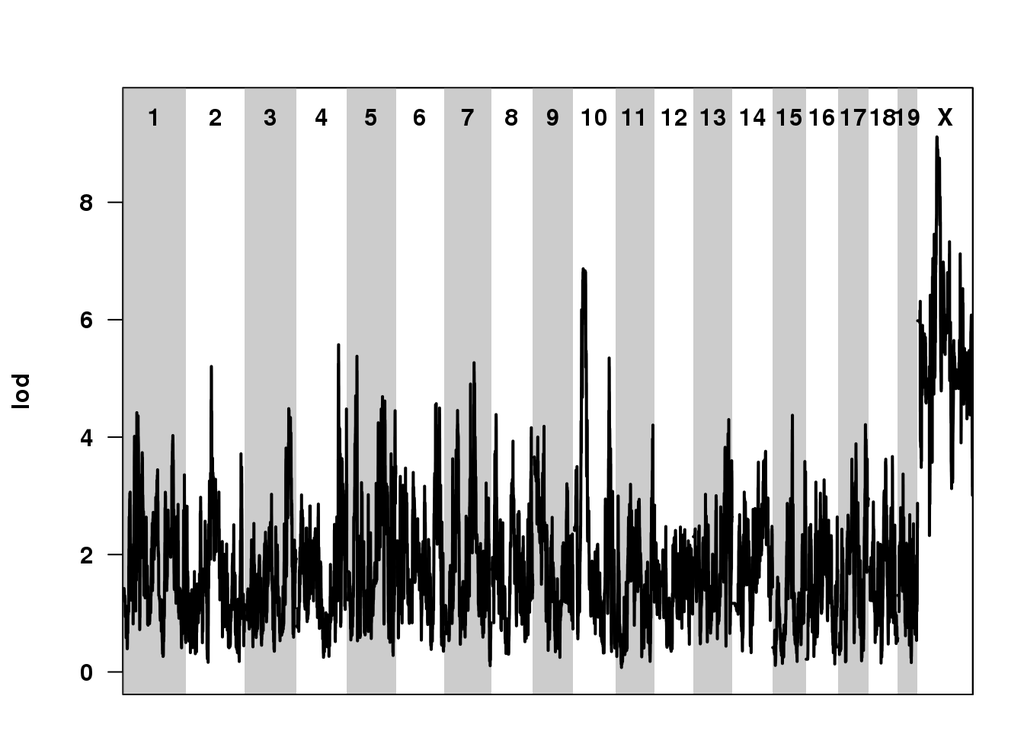

```r
plot(Glul.r.condp.scan)
```

Check the peak LOK score.

```r
indx.maxr.p <- with(Glul.r.condp.scan$lod$A, which(lod==max(lod)))
Glul.r.condp.scan$lod$A[indx.maxr.p,]
```

```
##                  SNP_ID Chr Mb_NCBI38       cM perc.var      lrs      lod
## 10_31348122 10_31348122  10  31.34812 17.39547 15.18565 31.62344 6.866944
##                       p neg.log10.p
## 10_31348122 4.76911e-05    4.321563
```

The peak marker is still on 10, very close, but the LOD score dropped to 6.87.

```r
Glul.r.condp.scan$lod$A[indx.maxr,]
```

```
##                  SNP_ID Chr Mb_NCBI38       cM perc.var      lrs      lod
## 10_30766019 10_30766019  10  30.76602 17.15718 14.96626 31.12743 6.759236
##                        p neg.log10.p
## 10_30766019 5.889758e-05    4.229903
```

At the original peak, the LOD drops to 6.76.

### Step 4: scan Glul protein conditioned on RNA

Modify covariates for conditional scan.

```r
covs <- data.frame(cbind(covs[,1:2],mydata$Glul.r))
#
Glul.p.condr.scan <- scanone(pheno=mydata, pheno.col="Glul.p", probs=probs.192,
                             addcovar=covs, snps=snps.64K)
```

```
## [1] "Mapping with 192 samples."
## [1] "Mapping with 64000 markers."
## [1] "Glul.p"
```

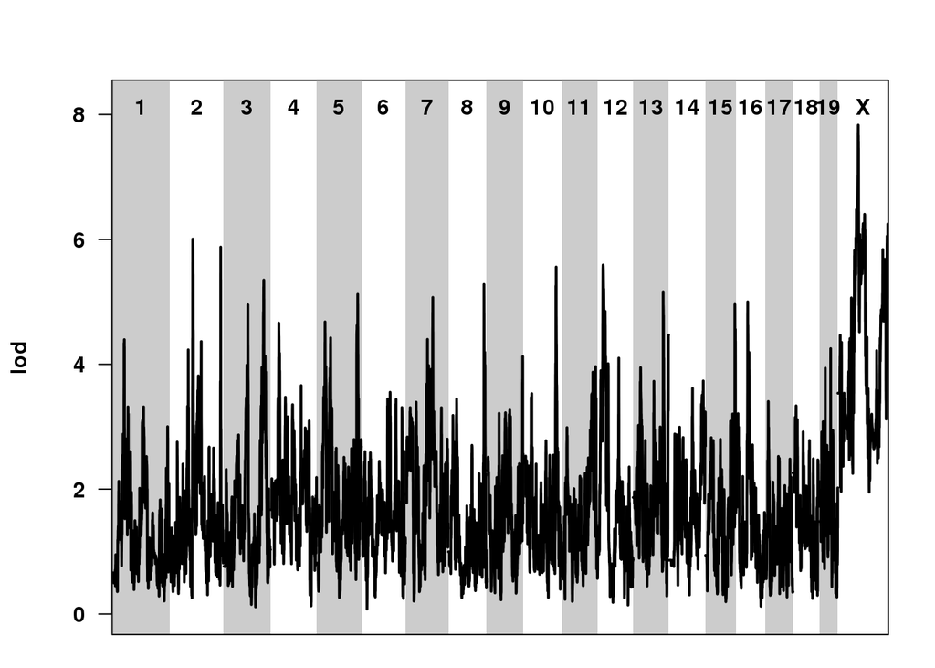

```r
plot(Glul.p.condr.scan)
```

Check the peak LOD.

```r
indx.maxp.r <- with(Glul.p.condr.scan$lod$A, which(lod==max(lod)))
Glul.p.condr.scan$lod$A[indx.maxp.r,]
```

```
##                SNP_ID Chr Mb_NCBI38       cM perc.var      lrs    lod
## 2_78032185 2_78032185   2  78.03218 46.60956 13.41707 27.66095 6.0065
##                       p neg.log10.p
## 2_78032185 0.0002532666    3.596422
```

The new peak marker is on chr 2.

```r
Glul.p.condr.scan$lod$A[indx.maxr,]
```

```
##                  SNP_ID Chr Mb_NCBI38       cM perc.var     lrs      lod
## 10_30766019 10_30766019  10  30.76602 17.15718 6.202822 12.2948 2.669782
##                      p neg.log10.p
## 10_30766019 0.09127157    1.039664
```

At the original peak, the LOD drops to 2.67.

Closing the plots will save memory.

```r
graphics.off()
```

Repeat mediation at the peak marker using linear model fitting.

Get the genotype probabilities at the peak marker.

```r
Q10 <- probs.192[,,"10_30766019"]
head(Q10)
```

```
##                 A            B            C            D            E
## F326 8.855617e-17 8.855617e-17 8.855616e-17 8.855618e-17 8.855616e-17
## F327 5.000000e-01 2.604126e-19 6.327880e-20 2.609318e-12 1.074055e-18
## F328 1.996653e-04 4.998002e-01 8.906467e-08 4.885424e-08 1.958094e-14
## F329 5.000000e-01 9.507840e-19 1.071116e-19 1.727085e-13 3.665145e-19
## F330 2.146766e-16 4.988142e-01 1.185845e-03 5.000000e-01 1.424361e-14
## F331 3.421542e-19 3.581670e-19 3.421484e-19 3.421485e-19 5.000000e-01
##                 F            G            H
## F326 1.000000e+00 8.855617e-17 8.855622e-17
## F327 5.000000e-01 1.831844e-20 7.915436e-19
## F328 9.653059e-17 9.654192e-17 5.000000e-01
## F329 1.679522e-18 1.017238e-26 5.000000e-01
## F330 6.754772e-15 1.437564e-34 1.794586e-14
## F331 5.000000e-01 2.587112e-18 7.419979e-19
```

Look at the frequency of founder alleles at the peak marker Expect 24 = 192/8

```r
apply(Q10,2,sum)
```

```
##         A         B         C         D         E         F         G
## 26.713670  7.017251 11.050413 23.230636 17.062188 47.094642 30.565040
##         H
## 29.266160
```

Note the low frequency of B6 and excess of CAST.

Add Q10 genotype probabilities into mydata.

```r
mydata <- data.frame(cbind(mydata[,1:8], Q10))
names(mydata)
```

```
##  [1] "Sex"     "Diet"    "Gen"     "Glul.r"  "Glul.p"  "SexDiet" "Parity"
##  [8] "Black"   "A"       "B"       "C"       "D"       "E"       "F"
## [15] "G"       "H"
```

Check for missing data!  
It is important to remove all cases with missing data before fitting linear models.

```r
sum(is.na(mydata$Glul.r))
```

```
## [1] 0
```

```r
sum(is.na(mydata$Glul.p))
```

```
## [1] 0
```

There are none in this example. Phew!

Here is what to do if you have missing data

```r
miss.indx <- which(is.na(mydata$Glul.r)|is.na(mydata$Glul.p))
mydata <- mydata[-miss.indx,]
```

Note that this will put your “mydata” out of register with the other data objects in this environment. Also note to self - should have paid attention to this in genome scans!!!

### Linear Model Tests

Linear model fit of Glul.r  
Q -> RNA ?

```r
anova(lm(Glul.r ~ Sex*Diet, data=mydata), lm(Glul.r ~ -1 + A + B + C + D + E + F + G + H + Sex*Diet, data=mydata))
```

[output not shown]

Linear model fit of Glul.p Q -> Prot ?

```r
anova(lm(Glul.p ~ Sex*Diet, data=mydata),
      lm(Glul.p ~ -1 + A + B + C + D + E + F + G + H + Sex*Diet, data=mydata))
```

[output not shown]

Linear model fit of Glul RNA conditioned on protein Q -> RNA | Prot ?

```r
anova(lm(Glul.r ~ Glul.p+Sex*Diet, data=mydata),
      lm(Glul.r ~ Glul.p+A + B + C + D + E + F + G + H + Sex*Diet, data=mydata))
```

[output not shown]

Linear model fit of Glul Prot condtioned on RNA Q -> Prot | RNA ?

```r
anova(lm(Glul.p ~ Glul.r+Sex*Diet, data=mydata),
      lm(Glul.p ~ Glul.r+A + B + C + D + E + F + G + H + Sex*Diet, data=mydata))
```

[output not shown]

Compare model coefficients

```r
RNA.coef <- coefficients(lm(Glul.r ~ -1 + A + B + C + D + E + F + G + H + Sex*Diet, data=mydata))[1:8]
Prot.coef <- coefficients(lm(Glul.p ~ -1 + A + B + C + D + E + F + G + H + Sex*Diet, data=mydata))[1:8]

ggplot(data.frame(RNA.coef, Prot.coef), aes(x=RNA.coef, y=Prot.coef)) +
  geom_text(label=names(RNA.coef)) +
  geom_smooth(method="lm")
```

[output not shown]

### Challenge: Glul is on chromosome 1, but the QTL is on chromosome 10. There must be a trans acting factor that is driving the variation in Glul expression. Can you find it?